# Praca domowa 3

Wiktoria Borys

2023-03-27

# Wstęp

Celem projektu jest sprawdzenie, czy określone problemy z czytaniem danych wciąż występują i czy praktyki wypracowane lata temu (np. słupki lepsze niż kąty) dalej działają w naszym społeczeństwie. Dane użyte do przeprowadenia eksperymentu pochodzą ze strony https://www.statista.com/statistics/1283935/most-viewed-netflix-show-english/.

# Opis eksperymentu

Dane wykorzystane w projekcie dotyczą anglojęzycznych seriali Netflixa, które według liczby godzin oglądania były najbardziej popularne (stan na luty 2023 r.).

Prezentują się one następująco:

```
##                                Nazwa serialu       Godziny oglądania
## 1                          Stranger Things 4                 1352.09
## 2                        Wednesday: Season 1                 1237.15
## 3  DAHMER: Monster: The Jeffrey Dahmer Story                  856.22
## 4                       Bridgerton: Season 2                  656.26
## 5                       Bridgerton: Season 1                  625.49
## 6                          Stranger Things 3                  582.10
## 7                          Lucifer: Season 5                  569.48
## 8                      The Witcher: Season 1                  541.01
## 9             Inventing Anna: Limited Series                  511.92
## 10                 Ginny & Georgia: Season 2                  504.77
```

Możemy zauważyć, że najpopularniejszym serialem według liczby godzin oglądania jest *Stranger Things 4*. Spośród wymienionych wyżej seriali najmniej popularnym jest natomiast *Ginny & Georgia: Season 2*.

Znalezione dane postanowiłam przedstawić za pomocą wykresu kołowego i słupkowego.

**Wykres kołowy:**

[figure not shown]

**Wykres słupkowy:**

[figure not shown]

Później przygotowałam krótką ankietę, podczas której pytałam o najbardziej i najmniej popularny serial bazując na wykresie kołowym. Następnie zadałam te same pytania w oparciu o wykres słupkowy.

W ankiecie odpowiedzi udzieliło 20 osób. Wyniki prezentują się następująco:

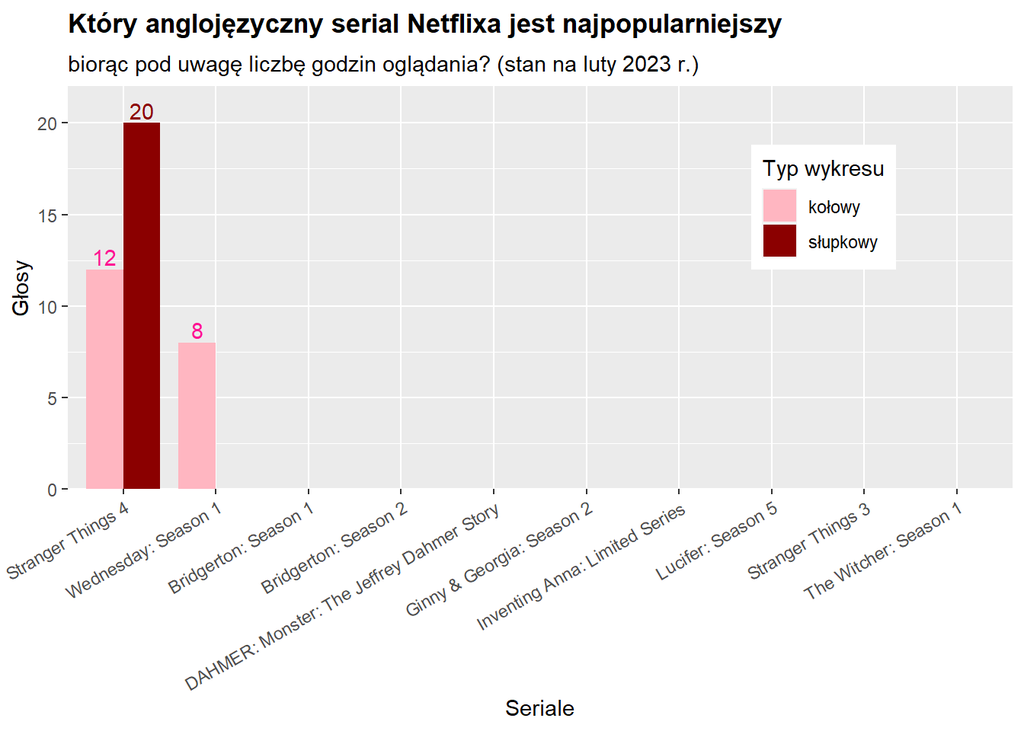

W oparciu o wykres kołowy 12 osób udzieliło poprawnej odpowiedzi, 8 natomiast wskazało *Wednesday: Season 1*, który był drugim najpopularniejszym serialem według liczby godzin oglądania.

Wszystkie osoby udzieliły prawidłowej odpowiedzi na pytanie w momencie gdy bazowały na wykresie słupkowym.

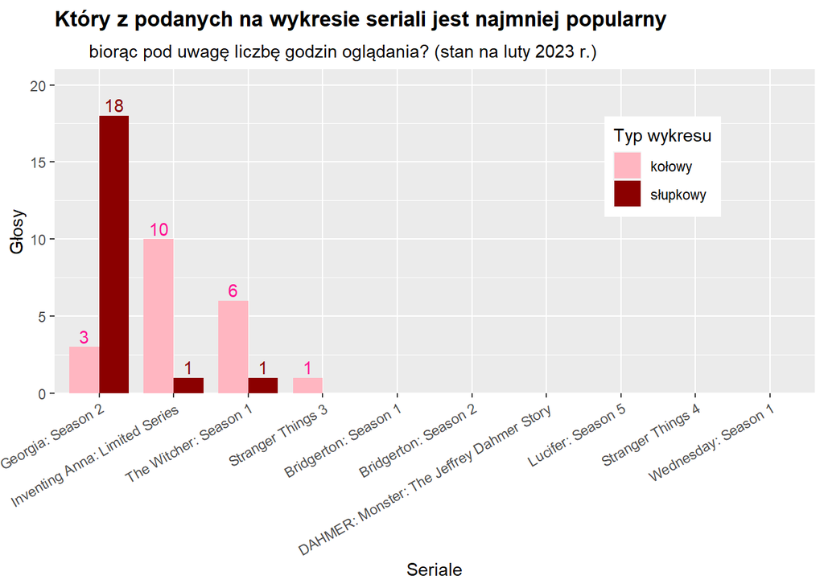

Bazując na wykresie kołowym, tylko 3 osoby odpowiedziały dobrze na pytanie. 10 ankietowanych wskazało *Inventing Anna: Limited Series*, 6 *The Witcher: Season 1* i 1 *Stranger Things 3*, które miały kolejno drugą, trzecią i piątą najmniejszą liczbę godzin oglądania spośród podanych seriali.

W oparciu o wykres słupkowy poprawnej odpowiedzi udzieliło 18 osób. Pozostałe 2 osoby wskazały *Inventing Anna: Limited Series* i *The Witcher: Season 1*.

Na koniec zapytałam, który wykres jest zdaniem pytanych bardziej czytelny i łatwiejszy w interpretacji. Odpowiedź była jednomyślna.

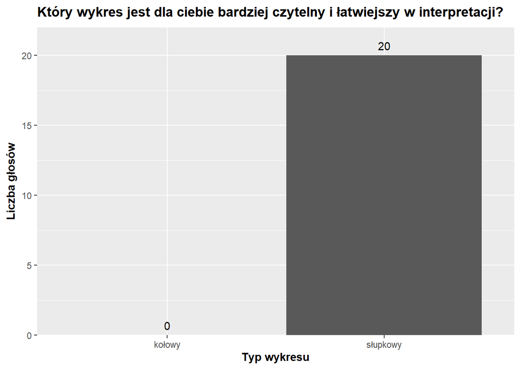

20 osób jednogłośnie uznało, że bardziej czytelny jest wykres słupkowy.

# Podsumowanie

Osoby testowane jednomyślnie stwierdziły, że wykres słupkowy jest łatwiejszy w interpretacji. Potwierdzają to także ich odpowiedzi na wcześniejsze pytania - w oparciu o wykres kołowy udzielono 25 błędnych odpowiedzi, w oparciu o słupkowy tylko 2.

Pokazuje to, że “dobre praktyki” opracowane lata temu wciąż działają w naszym społeczeństwie.